# Plus c’est mieux ? : la relation entre la proportion d’électeurs autochtone dans une circonscriptions et la participation électorale de ces derniers aux élections fédérales de 2021

William Beaudry

2024-11-16

# État du savoir

Être autochtone est une expérience qui regroupe les membres des différentes nations et communautés des Premières Nations du Canada et d’ailleurs. L’édification de l’État colonial canadien s’est fait au dépends des premiers peuples. Marginalisés, confinés à des réserves dépourvus de la plupart des droits politiques des autres citoyens du Canada, ce n’est qu’en 1960 que le gouvernement fédéral de John Diefenbaker leur octroi le vote. Certaines législatures provinciales l’avaient déjà fait ou l’on fait par la suite, le Québec étant la dernière province à leur donner le droit de vote en 1969, sans débats ni revendications.

Quels facteurs ont été mobilisés par les chercheurs pour expliquer la participation électorale des membres des Premières nations aux élections fédérales ? Plusieurs rapports postélectoraux ont mobilisé une approche centrée sur les ressources socio-économiques. Celles-ci sont univoques: les différences de statut socio-économique entre les membres des Premières nations et les Allochtones expliqueraient la moitié de l’écart de participation entre ces deux groupes (Harell et al., 2010). L’autre moitié de l’explication résiderait donc dans une expérience qui est proprement autochtone, donc des facteurs structurels.

Parmi les facteurs institutionnels, plusieurs auteurs se sont penché sur la question de la taille des circonscriptions électorales ainsi que du rôle de l’information politique fournies par les institutions électorales. La taille de l’électorat est un facteur multidimensionnel. Il peut d’abord être abordé sous l’angle du choix rationel, où les électeurs autochtones, évaluant la taille de leur communauté, choisissent ou non de voter s’ils croient que les membres de leur communauté peuvent influencer le choix du représentant en leur faveur (Hill et Alport, 2010).

Une autre dimension de la taille des circonscriptions, cette fois-ci faisant référence à son étendue géographique, est l’éloignement des communautés. Les électeurs éloignées de centres urbains ont une plus grande propension à être marginalisé par les partis politiques et la couverture médiatique lors de campagnes électorales étant donné des coûts de déplacement (Hill et Alport, 2010). Les communautés autochtones au Québec, étant généralement loin des centres urbains, pourraient faire fasse à ce genre d’enjeux d’éloignement, tandis que dans d’autres provinces, nombre de communautés sont plus près des centres urbains.

Une dernière dimension de la taille de la circonscription est sa composition démographique. Les circonscriptions électorales plus grandes en termes d’électeurs sont également plus diversifiées sur les aspects ethno-culturels. La diversité linguistiques surtout serait un facteur qui déprécient la participation électorale (Armstrong et al., 2024). Ici, vu la plus faible proportion d’électeurs autochtones dans les circonscriptions électorales, il serait probable que l’homogénéité de la circonscription soit un facteur discriminant les Premières nations. Si le facteur linguistique semble important, Harell et al. 2010 observent une corrélation entre la langue et la participation qui va à l’encontre des attentes: des communautés qui parlent le Cri participent davantage aux élections fédérales que celles parlant l’anglais courrament (Harell et al., 2010). Les Premières nations du Québec sont celles dont les langues traditionnelles sont les plus vivantes du pays et il en est de même pour les Nunavimmiut et l’usage de l’Inuktitut au sein de l’Inuit Nunangat. Cependant, cette relation peut être le produit de l’histoire et des contextes coloniaux propres aux différentes communautés (Harell et al. 2010). Comme la langue seconde de nombre de communautés autochtones au Québec est l’anglais, la vie dans un espace francophone pourrait intervenir comme facteur qui déprécie la participation électorale dans la province, ce qui ne serait pas le cas dans les autres provinces.

La question de recherche que nous nous posons alors est la suivante: *quelle est l’influence de la taille de la circonscription sur la participation aux élections fédérales de 2021 dans les communautés autochtones ?*

## Hypothèses

À partir de ce très bref État du savoir, nous en venons à découler une hypothèse. D’abord, nous nous attendons que la proportion plus faible d’électeurs autochtones dans la province du Québec ait plusieurs effets qui décourage la participation électorale.

*H1: la proportion d’électeurs autochtones dans une circonscription électorale est positivement associée à la participation électorale des électeurs autochtones*

*H2: la corrélation entre la proportion d’électeurs autochtones et le taux de participation de ces électeurs est plus faible au Québec que dans le reste du Canada*

## Sélection des sources bibliographiques

Pour produire cet état du savoir, nous avons eu recours à trois outils numériques de recherche. D’abord, nous avons entré notre question de recherche dans *Perplexity.ai* afin qu’il retravaille la question dans des termes optimaux pour produire une question pour le logiciel *Elicit*. Notre question de recherche « Comment expliquer la faible participation aux élections fédérales dans les Premières Nations du Québec comparativement à celles des autres provinces entre 2004 et 2011 ? » a été traduite ainsi « What factors explain the lower voter turnout in First Nations communities in Quebec compared to other Canadian provinces in federal elections between 2004 and 2021 ? » pour faire une requête dans *Elicit*.

Une fois la requête envoyé dans *Elicit*, nous avons sélectionnés les 16 premiers articles proposés. Ceux-ci étaient filtré en fonction de leur pertinence à répondre à la question de recherche et en fonction de la date. La période pour laquelle était choisi des textes étaient de 2004 à aujourd’hui.

En cours de route, la question de recherche a été changée en fonction de la disponibilité des données. Cela dit, les articles sélectionnées dans un premier temps permettaient de répondre à cette nouvelle question de recherche. Nous avons donc utilisé les mêmes articles.

# Méthodes et données

## Méthodes

Nous avons procédé à une régression linéaire simple où Y est le taux de participation des électeurs s’identifiant autochtone, X est la proportion d’électeurs autochtones dans la circonscription et β1 est le coefficient de régression.

## Extraction des données

**Charger les bibliothèques nécessaires** library(rvest) library(dplyr)

**URL de la page** url <- “https://www.elections.ca/content.aspx?dir=rec/part/fvt&document=p4&lang=f&section=res”

**Lire le contenu HTML de la page** page <- read_html(url)

**Extraire les lignes du tableau avec les balises “tr”** table_rows <- page %>% html_elements(“tr”)

**Récupérer le contenu des balises “th” (en-têtes de colonnes)** headers <- table_rows %>% .[1] %>% html_elements(“th”) %>% html_text()

**Extraire les données des balises “td” pour les rangées restantes** data <- table_rows %>% .[-1] %>% lapply(function(row) { row %>% html_elements(“td”) %>% html_text() })

**Convertir les données en data frame** df <- do.call(rbind, data) %>% as.data.frame(stringsAsFactors = FALSE)

**Attribuer les noms de colonnes extraits** names(df) <- headers

**Nettoyer et convertir les données numériques** df_cln <- df %>% mutate(across( .cols = -1, .fns = ~ { # Supprimer les espaces et remplacer la virgule par un point cleaned <- gsub(” “,”“, .) cleaned <- gsub(”,“,”.”, cleaned) # Convertir en numérique as.numeric(cleaned) } ))

Ce code nous a permit de créer une tableau des taux de participation des communautés autochtones aux élections fédérales de 2004 à 2011 ventilé selon la province.

Nous avons utilisé une deuxième source de données, soit la taille de la population dans les circonscriptions où se trouvent des communautés autochtones au Canada ainsi que le nombre d’électeurs autochtones inscrits et le taux de participation de ces électeurs. Les données étaient présentées dans un document CSV et dans un rapport institutionnel d’Élection Canada. La compilation des données d’électeurs autochtones inscrits et de la participation électorale ont été ajoutées manuellement au document CSV des données populationnelles de chaque circonscription.

Les données sont issues de 2021, ce qui pourrait potentiellement introduire un biais non-négligeable étant donnée que la croissance démographique des communautés autochtones est plus rapide que celles des communautés environnantes. Leur proportion dans les circonscriptions devrait avoir augmenté sensiblement entre 2011 et 2021. Cela dit, dans une perspective comparant les cas des communautés autochtones au Québec et celles du restes du Canada, il nous appert que la croissance relativement similaire entre les communautés des différentes provinces devrait être peu importante.

# Résultats

## Visualisation

Nous avons fait le choix de faire nos deux premières visualisations avec les données que nous avons extraites pour illustrer les faibles taux de participation aux élections fédérales dans les communautés autochotnes entre 2004 et 2011. La première visualisation est un graphique à ligne brisée pour montrer les tendances propres aux communautés de chaque provinces. Le second graphique est un diagramme en points. Il permet d’observer la différence importante de participation entre les communautés autochtones du Québec et les autres provinces canadiennes. Le code que nous avons roulé pour produire ces graphiques sont les suivants:

**Préparer les données** df_long <- df_cln %>% pivot_longer(cols = -“Province/territoire”, names_to = “Année”, values_to = “Taux_participation”)

df_long_filtered <- df_long %>% filter(“Province/territoire” != “Sections de vote dans les réserves”) %>% filter(Année != “Moyenne cumulative(%)”) %>% mutate(Année = as.numeric(gsub(“[^0-9]”, ““, Année)))

**Graphique linéaire** ggplot(df_long_filtered, aes(x = Année, y = Taux_participation, group = “Province/territoire”, color = “Province/territoire”)) + geom_line() + geom_point() + theme_minimal() + labs( title = str_wrap(“Taux de participation aux élections fédérales dans les communautés autochtones par province (2004-2011)”), x = “Année”, y = “Taux de participation (%)”, color = “Province” ) + theme( axis.text.x = element_text(angle = 45, hjust = 1), legend.position = “right” )

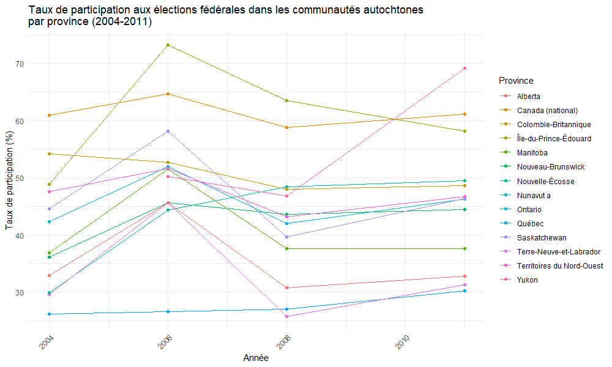

Graphique 1

**Créer un graphique boxplot** ggplot(df_long, aes(x = Année, y = Taux_participation, group = “Province/territoire”, color = “Province/territoire”)) + geom_line() + geom_point() + theme_minimal() + labs(title = “Taux de participation aux élections fédérales par province (2004-2011)”, x = “Année”, y = “Taux de participation (%)”, color = “Province”) + theme(axis.text.x = element_text(angle = 45, hjust = 1), legend.position = “right”) + scale_color_manual(values = “red”)

[figure not shown]

Graphique 2

Nous avons ensuite calculer la proportion d’électeurs autochtones dans 113 circonscriptions électorales fédérales en 2021 pour produire deux graphiques supplémentaires. Le premier illustre la corrélation entre la proportion d’électeurs autochtone et leur taux de participation tandis que le second distingue cette corrélation selon la province ou le territoire.

**Calcul de la proportion d’électeurs autochtones dans la population** df <- ED_Canada_2021_prov_tx_part %>% mutate(prop_indigenous = ELECTEURS_AUTOCHTONES / POPULATION)

**Calcul du coefficient de corrélation global** correlation <- cor(df$prop_indigenous, df$TAUX_PARTICIPATION, use = “complete.obs”)

**Création du graphique avec échelles logarithmiques** ggplot(df, aes(x = prop_indigenous, y = TAUX_PARTICIPATION)) + geom_point(alpha = 0.6, color = “blue”) + # Nuage de points geom_smooth(method = “lm”, color = “red”, se = TRUE) + # Ligne de régression scale_x_log10() + # Échelle logarithmique pour l’axe X labs( title = “Relation (log) entre la proportion d’électeurs autochtones et le taux de participation”, x = “Proportion d’électeurs autochtones (log10)”, y = “Taux de participation (%)” ) + theme_minimal() + theme( plot.title = element_text(hjust = 0.5), # Centrage du titre text = element_text(size = 12) )

[figure not shown]

Graphique 3

**Calculer la proportion d’électeurs autochtones** df <- df %>% mutate(prop_indigenous = ELECTEURS_AUTOCHTONES / POPULATION)

**Calcul des coefficients de corrélation par province** correlation_by_province <- df %>% group_by(PROV) %>% summarize( correlation = cor(prop_indigenous, TAUX_PARTICIPATION, use = “complete.obs”) )

**Calcul de la proportion d’électeurs autochtones** df <- df %>% mutate(prop_indigenous = ELECTEURS_AUTOCHTONES / POPULATION)

**Création d’un graphique avec une facette par province** ggplot(df, aes(x = prop_indigenous, y = TAUX_PARTICIPATION, color = PROV)) + geom_point(size = 1, alpha = 0.7) + geom_smooth(method = “lm”, se = FALSE, linetype = “dashed”, size = 1) + # Droites de régression scale_x_log10() + labs( title = “Proportion d’électeurs autochtones vs Taux de participation”, x = “Proportion d’électeurs autochtones (log10)”, y = “Taux de participation (%)” ) + facet_wrap(~PROV) + theme_minimal() + theme( plot.title = element_text(hjust = 0.5), # Centrage du titre text = element_text(size = 12), legend.position = “none” # Supprime la légende pour chaque facette )

[figure not shown]

Graphique 4

Ces codes ont été utilisés pour trouver et illustrer le coefficient de corrélation entre la proportion d’électeurs autochtones dans les circonscriptions fédérales et le taux de participation de ces électeurs en 2021. Nous avons fait un coefficient pour l’ensemble des circonscriptions, puis elles ont été regroupées selon la province, puis divisé entre le Québec et les reste du Canada.

Pour ce qui est de la participation aux élections de 2021, la corrélation entre la proportion d’électeurs autochtones dans une circonscription et la participation électorale n’est pas plus négative au Québec que dans d’autres provinces. Le coefficient de corrélation est de -0,235 au Québec tandis qu’ils est plus négatif en Ontario (-0,296), en Nouvelle-Écosse (-,370), au Manitoba (-0,433) et en Saskatchewan (-0,645). Cependant, au sein de l’ensemble canadien, le coefficient de corrélation de la province de Québec est inférieur à celui de toutes les provinces qui est de -0,112.

# Conclusion et discussion

D’après les données que nous avons utilisées, nos hypothèses sont infirmées. Le coefficient de corrélation, bien que faible, montre que la relation entre la taille de la circonscription est au mieux associée à un faible effet négatif sur la participation électorale, sinon une corrélation nulle. Cette conclusion vient à l’encontre de la théorie du choix rationnel que nous testions avec l’hypothèse 1.

Quant à l’hypothèse 2, elle est également infirmée par nos résultats. Nous nous attendions à observer une relation positive entre nos deux variables dans toutes les provinces, mais plus faibles au Québec. Or, au Québec, elle est négative comme dans plusieurs autres provinces, mais elle est plus faible que plusieurs autres provinces. Ainsi, la relation entre le taux de participation et la proportion d’électeurs autochtones est plus faible que dans plusieurs autres provinces, ce à quoi nous ne nous attendions pas.

En somme, une différence entre le taux de participation ne peut être attribué à la taille, et son corrolaire la proportion d’électeurs autochtones, pour expliquer le taux de participation des électeurs autochtones du Québec et du reste du Canada.

Pour aller plus loin, une analyse qui souhaiterait mobiliser la taille des circonscriptions devrait inclure les variables sociodémographiques puisque les circonscription qui ont proportion plus élevée d’électeurs autochtones se situent généralement en région éloignée. L’accès à l’information, la couverture médiatique des campagnes électorales ou encore le profil sociodémographiques des électeurs se distinguent généralement des circonscriptions métropolitaines.

# Choix des outils

L’utilisation de R a été un choix évident pour réaliser ce projet, et ce pour quatre raisons. La première est la popularité de l’outil dans communauté scientifique de science politique. Ce court projet nous aura permis de se familiariser et d’acquérir des habilités techniques pour faire de la recherche pour les prochaines années. La deuxième raison est l’accessibilité de l’outil: la présence dde logiciel d’Intelligence artificielle, d’une large communauté d’utilisateur et de sa gratuité diminue le coût d’acquisition bien plus faible étant donné que les problèmes rencontrés ont généralement été répertoriés par d’autres chercheurs et peuvent facilement être controurné avbec l’aide de l’IA. En plus, sa gratuité permet d’en faire un outil de choix puisqu’il n’est pas dit qu’un employeur futut souscrira à une license onéreuse d’un logiciel propriétaire concurrent. Enfin, la troisième raison pour laquelle cet outil a été utilisé est pour la transparence et la réplicabilité du processus, des valeurs qui émergent rapidement dans le domaine. Les codes qui nous ont permis de générer nos résultats sont accessibles à la communauté qui pourra le rouler elle-même assurer de la véracité de nos analyses. La dernière raison est la capacité de faire toutes les étapes de la recherche au sein du même outil. Ici, nous avons extraits des données, analyser et visualiser les données, ce qui est un avantage indéniable pour éviter les erreurs ou les pertes de temps liées transférer les données d’un logiciel à l’autre.

# Bibliographie

Armstrong, D. A., Alcantara, C., & Kennedy, J. (2023a). Exploring the effects of electorate size on indigenous voter turnout. Politics, Groups, and Identities, 11(1), 98‑107. https://doi.org/10.1080/21565503.2021.1926297

Harellll, A., Panagos, D., & Matthews, J. (2010). Explaining Aboriginal Turnout in Federal Elections : Evidence from Albe rta, Saskatchewan, and Manitoba.

Hill, L., & Alport, K. (2010). Voting Attitudes and Behaviour Among Aboriginal Peoples : Reports from Anangu Women. Australian Journal of Politics & History, 56(2), 242‑258. https://doi.org/10.1111/j.1467-8497.2010.01552.x